# The Great American Coffee Taste Test

## Can we predict how much coffee a person is going to drink a day based on how strongly needs coffee?

We will examine if the number of children (which presumably causes fatigue) and how strongly they need caffeine (the level of caffeine and strengths of the coffee).

```r
# Cleaning the data
# Selecting the columns
selected_data <- c("number_children", "caffeine", "strength", "cups")
coffee_data_select <- coffee_data %>%
  select(all_of(selected_data))

# Remove missing values
coffee_data_clean <- coffee_data_select %>% drop_na()
```

```r
# Recoding variables
coffee_data_clean$cups[coffee_data_clean$cups == "More than 4"] <- "5"
coffee_data_clean$cups[coffee_data_clean$cups == "Less than 1"] <- "0"
coffee_data_clean$number_children[coffee_data_clean$number_children == "More than 3"] <- "4"
coffee_data_clean$number_children[coffee_data_clean$number_children == "None"] <- "0"
coffee_data_clean$caffeine[coffee_data_clean$caffeine == "Decaf"] <- "0"
coffee_data_clean$caffeine[coffee_data_clean$caffeine == "Half caff"] <- "1"
coffee_data_clean$caffeine[coffee_data_clean$caffeine == "Full caffeine"] <- "2"
coffee_data_clean$strength[coffee_data_clean$strength == "Weak"] <- "1"
coffee_data_clean$strength[coffee_data_clean$strength == "Somewhat light"] <- "2"
coffee_data_clean$strength[coffee_data_clean$strength == "Medium"] <- "3"
coffee_data_clean$strength[coffee_data_clean$strength == "Somewhat strong"] <- "4"
coffee_data_clean$strength[coffee_data_clean$strength == "Very strong"] <- "5"

# Set variables numeric
coffee_data_clean$cups <- as.numeric(coffee_data_clean$cups)
coffee_data_clean$number_children <- as.numeric(coffee_data_clean$number_children)
coffee_data_clean$caffeine <- as.numeric(coffee_data_clean$caffeine)
coffee_data_clean$strength <- as.numeric(coffee_data_clean$strength)
```

```r
complex_model <- lm(cups ~ ., data = coffee_data_clean)
summary(complex_model)
```

```
##
## Call:
## lm(formula = cups ~ ., data = coffee_data_clean)
##
## Residuals:
##     Min      1Q  Median      3Q     Max
## -2.3012 -0.7620  0.0456  0.4114  3.8782
##
## Coefficients:
##                 Estimate Std. Error t value Pr(>|t|)
## (Intercept)      0.07791    0.09714   0.802    0.423
## number_children  0.17344    0.01770   9.798   <2e-16 ***
## caffeine         0.46682    0.03872  12.055   <2e-16 ***
## strength         0.19235    0.02064   9.319   <2e-16 ***
## ---
## Signif. codes:  0 '***' 0.001 '**' 0.01 '*' 0.05 '.' 0.1 ' ' 1
##
## Residual standard error: 0.9396 on 3378 degrees of freedom
## Multiple R-squared:  0.1001, Adjusted R-squared:  0.09926
## F-statistic: 125.2 on 3 and 3378 DF,  p-value: < 2.2e-16
```

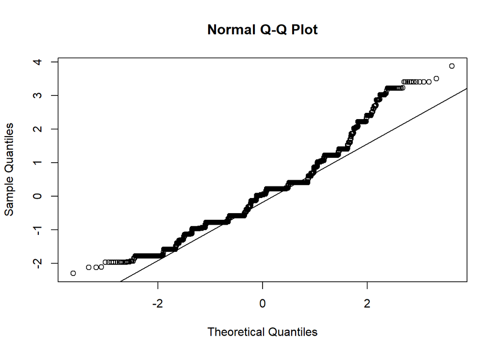

```r
# Check normality assumption
qqnorm(residuals(complex_model))
qqline(residuals(complex_model))
```

```r
# Shapiro-Wilk test
shapiro.test(residuals(complex_model))
```

```
##
##  Shapiro-Wilk normality test
##
## data:  residuals(complex_model)
## W = 0.95554, p-value < 2.2e-16
```

```r
# Rainbow test
raintest(complex_model)
```

```
##
##  Rainbow test
##
## data:  complex_model
## Rain = 1.1658, df1 = 1691, df2 = 1687, p-value = 0.0008164
```

```r
# Breusch-Pagan test
bptest(complex_model)
```

```
##
##  studentized Breusch-Pagan test
##
## data:  complex_model
## BP = 11.188, df = 3, p-value = 0.01075
```

```r
# Check the multicollinearity assumption
vif(complex_model)
```

```
## number_children        caffeine        strength
##        1.000317        1.025048        1.024905
```

```r
# Calculate robust standard errors
robust_se <- vcovHC(complex_model, type = "HC1")

# Display coefficients with robust standard errors
coeftest(complex_model, vcov = robust_se)
```

```
##
## t test of coefficients:
##
##                 Estimate Std. Error t value Pr(>|t|)
## (Intercept)     0.077906   0.088145  0.8838   0.3768
## number_children 0.173438   0.018903  9.1752   <2e-16 ***
## caffeine        0.466816   0.036335 12.8475   <2e-16 ***
## strength        0.192346   0.020871  9.2160   <2e-16 ***
## ---
## Signif. codes:  0 '***' 0.001 '**' 0.01 '*' 0.05 '.' 0.1 ' ' 1
```

### Results

We performed a linear regression analysis to examine the relationship between the selected variables. To account for that the residuals are not normally distributed and the heteroscedasticity we used robust standard errors. - The intercept is not significant. - The number of children are significant predictor of daily coffee consumption, 0.1734 (p < 0.000). - The quantity of caffeine in a cup of coffee are significant predictor of daily coffee consumption, 0.4668 (p < 0.000). - The strength of the coffee are significant predictor of daily coffee consumption, 0.1923 (p < 0.000).

```r
# Presenting the results in a table
# Extract coefficients, robust standard errors, t-values, and p-values
coefficients <- coef(summary(complex_model))
robust_se_vals <- sqrt(diag(robust_se))
t_values <- coefficients[, "Estimate"] / robust_se_vals
p_values <- 2 * pt(-abs(t_values), df = df.residual(complex_model))

# Create a data frame for the table
regression_results <- data.frame(
  Estimate = coefficients[, "Estimate"],
  `Robust Std. Error` = robust_se_vals,
  `t value` = t_values,
  `Pr(>|t|)` = p_values
)

# Format and display the table
regression_results %>%
  kable(format = "html", digits = 4, col.names = c("Predictor", "Estimate", "Robust Std. Error", "t value", "Pr(>|t|)")) %>%
  kable_styling(full_width = F, bootstrap_options = c("striped", "hover", "condensed")) %>%
  column_spec(1, bold = TRUE) %>%
  add_header_above(c("Regression Coefficients" = 5))
```

| Regression Coefficients Predictor | Regression Coefficients Estimate | Regression Coefficients Robust Std. Error | Regression Coefficients t value | Regression Coefficients Pr(>\|t\|) |
| --- | --- | --- | --- | --- |
| (Intercept) | 0.0779 | 0.0881 | 0.8838 | 0.3768 |
| number_children | 0.1734 | 0.0189 | 9.1752 | 0.0000 |
| caffeine | 0.4668 | 0.0363 | 12.8475 | 0.0000 |
| strength | 0.1923 | 0.0209 | 9.2160 | 0.0000 |

### Discussion

The analysis indicates that all of the tested factors contributes positively for the daily coffee consumption. The more children someone has and the stronger they like coffee, the more they will consume in a day.